# Análisis de datos de los ingresantes a los colegios de la Universidad Nacional de Cuyo para el año 2023

Rodrigo Gonzalez y Carlos A. Catania

04/03/2023

Todos los años alrededor de noviembre, miles de estudiantes del nivel de educación primaria en la provincia de Mendoza postulan a una vacante para ingresar a algunas de las 5 escuelas secundarias que posee la [Universidad Nacional de Cuyo](https://www.uncuyo.edu.ar/secundarios) (UNCuyo) en el Gran Mendoza. Estos colegios son Colegio Universitario Central “José de San Martín” (CUC), Departamento de Aplicación Docente (DAD), Liceo Agrícola y Enológico “Domingo F. Sarmiento” (LAE), Escuela del Magisterio (MAG) y Escuela de Comercio “Martín Zapata” (MZ). A su vez, cada colegio ofrece diferentes orientaciones como en Economía, Ciencias Sociales, Ciencias Naturales, Informática, entre otras. Los 5 colegios ofrecen 8 orientaciones en total. Cabe mencionar que el LAE hace su selección de ingreso antes y por separado del resto de los 4 colegios restantes. De todas formas, se ha decidido incluirlo en este análisis.

Los ingresantes a las escuelas de nivel secundario de la UNCuyo se dividen en dos grupos bien definidos.

Por un lado están los ingresantes por orden de mérito que compiten con un promedio que se forma al tomar las notas de cuarto a sexto grado de Lengua, Matemáticas, Ciencias Sociales, Ciencias Naturales, Educación Física y Educación Artística.

Los postulantes deben determinar el orden de preferencia de las 13 ofertas de escuela y orientación, de mayor a menor (ver tabla 3). Así, mientras mayor sea su promedio, más probable será obtener un banco en el colegio y orientación deseados, según el orden asignado.

Por otro lado, los egresados de la escuela de nivel primario Carmen Vera Arena (CVA), la cual es la única escuela de nivel primario administrada por la UNCuyo, pueden ingresar a los colegios de nivel secundario de la UNCuyo sin postular con un promedio de notas. Por el solo hecho de ser egresados del CVA tienen asegurado un banco en alguno de los colegios de nivel secundario de la UNCuyo. Se les asignan 5 plazas como máximo de un total de 30 por división. En otras palabras, el 16% de las vacantes son ofrecidas en primer término a los alumnos de séptimo grado de la CVA. Las vacantes restantes serán tomadas por los ingresantes por orden de mérito.

El objetivo de este informe es el de analizar cómo se distribuyen los promedios de los ingresantes por orden de mérito, para de esta manera ver las notas máximas y notas de corte por orientación, qué colegios y orientaciones son los más competitivos y cuáles menos. Adicionalmente, se revelan las preferencias de ingreso de los egresados de la escuela Carmen Vera Arena.

Todo el código de programación utilizado en este informe puede ser bajado del siguiente [link](https://github.com/rodralez/uncuyo-ingreso/code).

## Extracción de datos

Los resultados de la convocatoria son publicados por la UNCuyo en formato pdf para los colegios CUC, DAD, MAG y MZ por un lado, y para el LAE por otro. Dichos documentos contienen una tabla con el número de inscripción, el promedio del ingresante y el colegio y orientación al que ha accedido. Es necesario extraer estos datos y transformarlos a un formato más apropiado para facilitar su análisis.

## Análisis de los datos

### Total de ingresantes por orden de mérito

La UNCuyo ofreció un total de 1020 vacantes para los colegios secundarios del Gran Mendoza.

De un total de 1020 vacantes, se otorgaron 967 plazas a los ingresantes por orden de mérito. Las restantes 53 vacantes fueron previamente ocupadas por los alumnos del Carmen Vera Arena (CVA).

### Ingresantes por escuela

En la tabla 1 se muestra cómo se distribuyen por colegio los ingresantes por orden de mérito y los ingresantes del CVA. Además se muestra el porcentaje de ingresos del CVA, según el total de ingresantes de esta escuela (53). La tabla se ordena por la cantidad de ingresos del CVA, de mayor a menor.

Tabla 1: Distribución de los ingresantes por escuela.

| Escuela | Vacantes | Ingresantes | CVA | CVA_% |
| --- | --- | --- | --- | --- |
| CUC | 180 | 158 | 22 | 41.51 |
| MZ | 240 | 227 | 13 | 24.53 |
| LAE | 90 | 83 | 7 | 13.21 |
| DAD | 360 | 354 | 6 | 11.32 |
| MAG | 150 | 145 | 5 | 9.43 |

Se observa que el 42% de los egresados de CVA ha elegido ingresar al CUC. Le siguen MZ con un 25% y LAE con un 13%.

Esto es un adelanto de las preferencias de los ingresantes por órden de mérito que se observarán en las siguientes secciones.

### Ingresantes por orientación

En la tabla 2 se unifican las 8 orientaciones que ofrecen los 5 colegios y se expone cómo se distribuyen por orientación los ingresantes por orden de mérito y los ingresantes del CVA. Además se muestra el porcentaje de ingresantes del CVA, según el total de ingresantes de esta escuela (53). La tabla se ordena por la cantidad de ingresos del CVA, de mayor a menor.

Tabla 2: Distribución de los ingresantes por orientación.

| Orientacion | Vacantes | Ingresantes | CVA | CVA_% |
| --- | --- | --- | --- | --- |
| Ciencias Naturales | 210 | 195 | 15 | 28.30 |
| Ciencias Sociales | 330 | 320 | 10 | 18.87 |
| Arte | 60 | 53 | 7 | 13.21 |
| Tecnología Alimentaria | 90 | 83 | 7 | 13.21 |
| Economía | 120 | 114 | 6 | 11.32 |
| Informática | 60 | 54 | 6 | 11.32 |
| Comunicación | 30 | 29 | 1 | 1.89 |
| Lenguas | 120 | 119 | 1 | 1.89 |

### Ingresantes por escuela y orientación

En la tabla 3 se muestran cómo se distribuyen por escuela y por orientación los ingresantes por orden de mérito y los ingresantes del CVA. Además, se muestra el porcentaje de ingresos del CVA y el porcentaje de vacantes efectivas, esto es, las vacantes que no fueron tomadas por los alumnos del CVA. La tabla se ordena por el porcentaje de vacantes efectivas, de menor a mayor.

Tabla 3: Distribución de los ingresantes por escuela y orientación.

| Escuela | Orientacion | Vacantes | Ingresantes | CVA | CVA_% | Vacantes_ef_% |
| --- | --- | --- | --- | --- | --- | --- |
| CUC | Ciencias Naturales | 60 | 50 | 10 | 18.87 | 83.3 |
| CUC | Arte | 60 | 53 | 7 | 13.21 | 88.3 |
| MZ | Informática | 60 | 54 | 6 | 11.32 | 90.0 |
| MAG | Ciencias Naturales | 30 | 27 | 3 | 5.66 | 90.0 |
| CUC | Ciencias Sociales | 60 | 55 | 5 | 9.43 | 91.7 |
| LAE | Tecnología Alimentaria | 90 | 83 | 7 | 13.21 | 92.2 |
| MZ | Economía | 120 | 114 | 6 | 11.32 | 95.0 |
| MAG | Comunicación | 30 | 29 | 1 | 1.89 | 96.7 |
| DAD | Ciencias Sociales | 120 | 117 | 3 | 5.66 | 97.5 |
| DAD | Ciencias Naturales | 120 | 118 | 2 | 3.77 | 98.3 |
| MZ | Ciencias Sociales | 60 | 59 | 1 | 1.89 | 98.3 |
| MAG | Ciencias Sociales | 90 | 89 | 1 | 1.89 | 98.9 |
| DAD | Lenguas | 120 | 119 | 1 | 1.89 | 99.2 |

Se observa que los alumnos del CVA prefieren un 19% Ciencias Naturales del CUC, un 13% Arte del CUC y un 13% Tecnología Alimentaria del LAE.

Adicionalmente, en el caso de Ciencias Naturales, se ve que se han tomado el máximo de vacantes disponibles para este grupo de ingresantes, 5 vacantes por división, es decir, 10 vacantes en total. Esto indica una importante demanda por esta orientación y colegio.

Debido a que las 3 primeras orientaciones en la tabla 3, Ciencias Naturales del CUC, Arte del CUC e Informática del MZ, solo ofrecen 60 vacantes cada una, esto produce que se ofrezcan relativamente menos plazas para los ingresantes por orden de mérito en dichas orientaciones. Esto se observa en los porcentajes de vacantes efectivas con 83%, 88% y un 90%, respectivamente. Al final de la tabla se observa que solo 1 alumno del CVA ha elegido ingresar a Lenguas del DAD. Por último, se observa que todas las orientaciones y escuelas han recibido al menos 1 alumno del CVA.

### Análisis estadístico por escuela y orientación

En esta sección se expone el análisis estadístico de los promedios de los ingresantes por orden de mérito (sin CVA), lo que deriva en obtener los mejores promedios y promedios de corte por escuela y orientación. La siguiente tabla muestra por escuela y orientación: el promedio más alto (Maximo), el promedio de corte o mínimo promedio (Corte) y la mediana de los promedios (Mediana), todos ordenados por el promedio de corte, de mayor a menor.

Tabla 4: Análisis estadístico por escuela y orientación.

| Escuela | Orientacion | Maximo | Mediana | Corte |
| --- | --- | --- | --- | --- |
| CUC | Ciencias Naturales | 10 | 10.000 | 9.985 |
| MZ | Informática | 10 | 10.000 | 9.985 |
| CUC | Arte | 10 | 9.985 | 9.971 |
| CUC | Ciencias Sociales | 10 | 10.000 | 9.971 |
| MZ | Economía | 10 | 10.000 | 9.971 |
| MAG | Ciencias Naturales | 10 | 9.971 | 9.957 |
| MZ | Ciencias Sociales | 10 | 9.971 | 9.957 |
| LAE | Tecnología Alimentaria | 10 | 9.985 | 9.930 |
| MAG | Ciencias Sociales | 10 | 9.944 | 9.930 |
| MAG | Comunicación | 10 | 9.944 | 9.929 |
| DAD | Ciencias Sociales | 10 | 9.943 | 9.915 |
| DAD | Ciencias Naturales | 10 | 9.930 | 9.902 |
| DAD | Lenguas | 10 | 9.902 | 9.888 |

Se advierte que las mayores notas de cortes están en Ciencias Naturales del CUC, Informática del MZ y Artes y Ciencias Sociales, ambas del CUC, y en Economía del MZ. Esto quiere decir que los ingresantes con mejores promedios han postulado a algunas de estas 5 combinaciones. En el otro extremo, Lenguas del DAD presenta la nota de corte más baja. Cabe destacar que la mediana es de 10 para Ciencias Naturales y Ciencias Sociales del CUC, y para Informática y Economía del MZ. Esto indica que al menos la mitad de los ingresantes en estas 4 orientaciones tiene un promedio igual a 10.

### ¿A qué escuelas y orientaciones van los 10?

Se analiza a continuación a qué escuela y orientación postulan aquellos ingresantes que tienen un promedio igual a 10, es decir, los ingresantes con los promedios más altos, típicamente abanderados en sus escuelas de nivel primario de origen. Los datos se ordenan por el porcentaje de dieces, de mayor a menor.

Tabla 5: Distribución por escuela de los promedios iguales a 10.

| Escuela | Ingresantes | Dieces | Dieces_% |
| --- | --- | --- | --- |
| CUC | 158 | 95 | 60.1 |
| MZ | 227 | 119 | 52.4 |
| LAE | 83 | 29 | 34.9 |
| DAD | 354 | 45 | 12.7 |
| MAG | 145 | 18 | 12.4 |

Tabla 6: Distribución por escuela y orientación de los promedios iguales a 10.

| Escuela | Orientacion | Ingresantes | Dieces | Dieces_% |
| --- | --- | --- | --- | --- |
| MZ | Informática | 54 | 50 | 92.59 |
| CUC | Ciencias Naturales | 50 | 39 | 78.00 |
| CUC | Ciencias Sociales | 55 | 30 | 54.55 |
| MZ | Economía | 114 | 60 | 52.63 |
| CUC | Arte | 53 | 26 | 49.06 |
| LAE | Tecnología Alimentaria | 83 | 29 | 34.94 |
| MAG | Ciencias Naturales | 27 | 5 | 18.52 |
| DAD | Ciencias Naturales | 118 | 18 | 15.25 |
| MZ | Ciencias Sociales | 59 | 9 | 15.25 |
| DAD | Ciencias Sociales | 117 | 16 | 13.68 |
| MAG | Ciencias Sociales | 89 | 11 | 12.36 |
| DAD | Lenguas | 119 | 11 | 9.24 |
| MAG | Comunicación | 29 | 2 | 6.90 |

La tabla 5 muestra el total de promedios igual a 10 que recibe cada escuela. Se observa que el CUC es la escuela con mayor porcentaje de dieces respecto a sus ingresantes por orden de mérito con un 60%. Le sigue el MZ con 52%. Más lejos se encuentran LAE, DAD y MAG con 35%, 13% y 12%, respectivamente. Cabe destacar que de un total de 967 ingresantes por orden de mérito, 306 poseen un promedio igual a 10, esto es, casi un 32% del total de ingresantes poseen los promedios más altos posibles.

En la tabla 6 se ven las orientaciones con mayor demanda entre los ingresantes con promedio igual a 10. En los primeros lugares se ubican Informática del MZ, Ciencias Naturales del CUC, Ciencias Sociales del CUC y Economía del MZ, con 93%, 78%, 55% y 53%, respectivamente.

## ¿Cómo se distribuyen los promedios de los ingresantes por orden de mérito?

Se muestra cómo se distribuyen estos promedios por colegio y por orientación en un gráfico aluvional. El eje *y* de las figuras representa la cantidad de ingresantes por orden de mérito. Las alturas de las cajas para los rangos R1, R2, R3, etc., representan la proporción de ingresantes que se encuentran en cada una de estas categorías.

Tabla 7: Rangos de promedios.

| Etiqueta | Rangos | Ingresantes |
| --- | --- | --- |
| R1 | (9.999,10] | 306 |
| R2 | (9.95,9.999] | 341 |
| R3 | (9.9,9.95] | 311 |
| R4 | (9.85,9.9] | 9 |

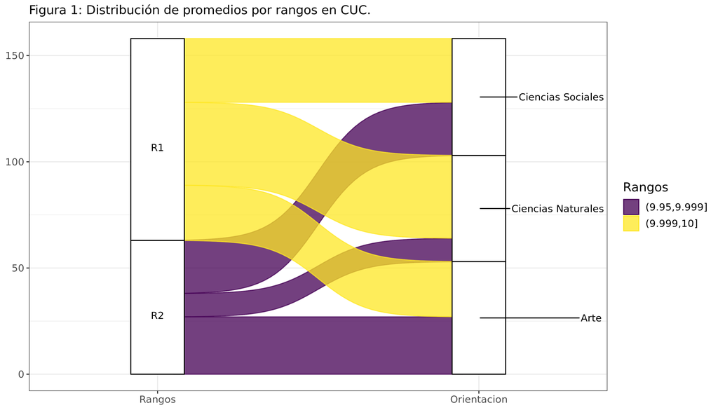

La figura 1 expone que el CUC solo recibe promedios de los rangos R1 y R2. Se verifica que Ciencias Naturales solo admite los mejores promedios, mayoritariamente los que están en el rango R1.

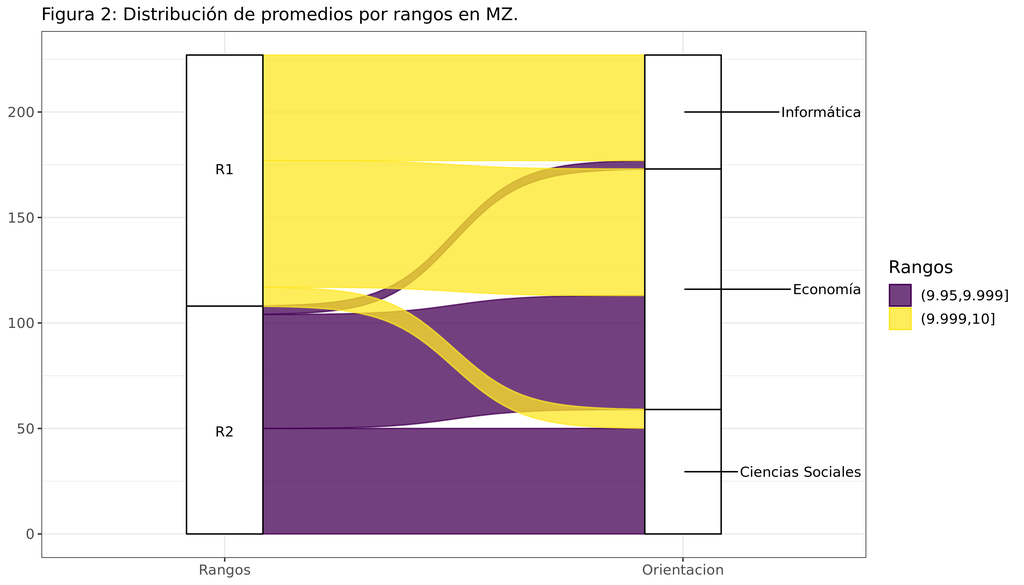

La figura 2 muestra que el MZ solo recibe promedios de los rangos R1 y R2. Informática está compuesta mayoritariamente por promedios del rango R1. Economía capta promedios de los rangos R1 y R2. Finalmente, Ciencias Sociales recibe mayoritariamente promedios de R2.

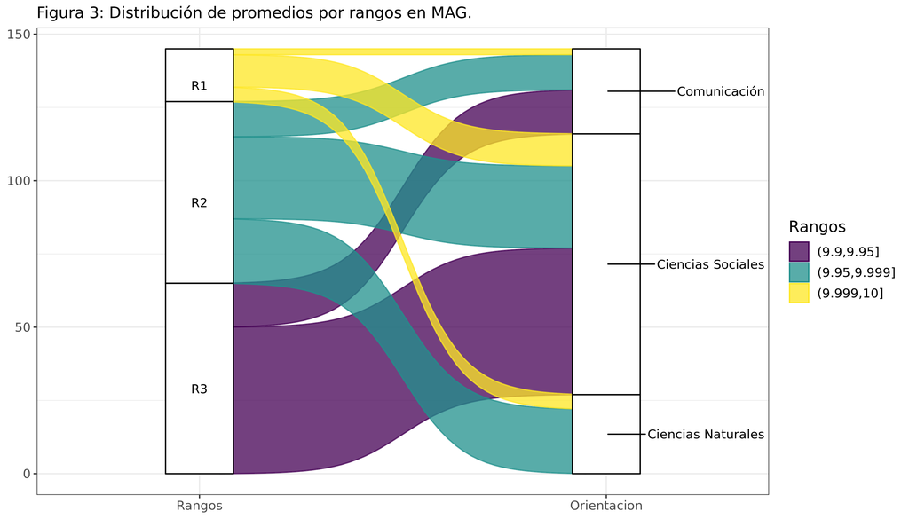

Se observa en la figura 3, como en el caso del CUC, Ciencias Naturales del MAG también recibe los mejores promedios en los rangos R1 y R2. Las restantes orientaciones, Comunicación y Ciencias Sociales, reciben promedios de los rangos R1, R2 y R3 en prácticamente las mismas proporciones.

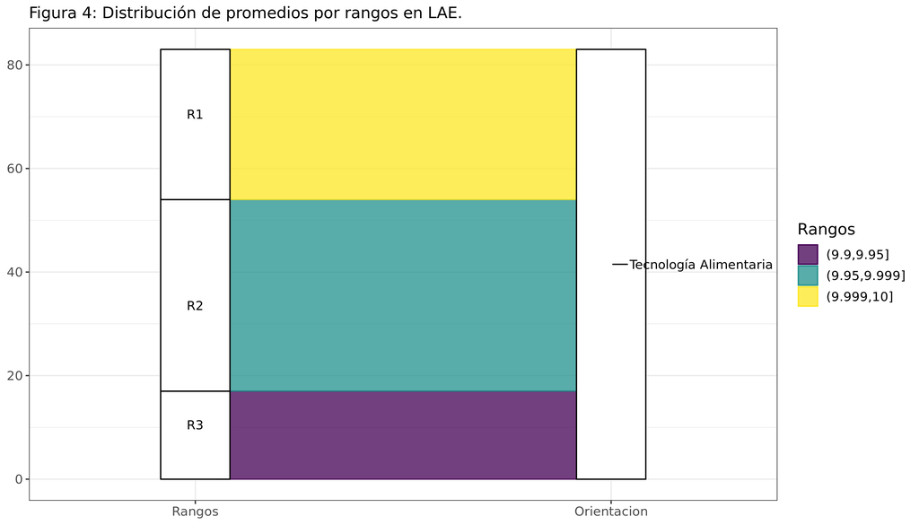

En la figura 4 se ve que la única orientación que ofrece el LAE recibe promedios de los 3 primeros rangos, mayoritariamente de R2.

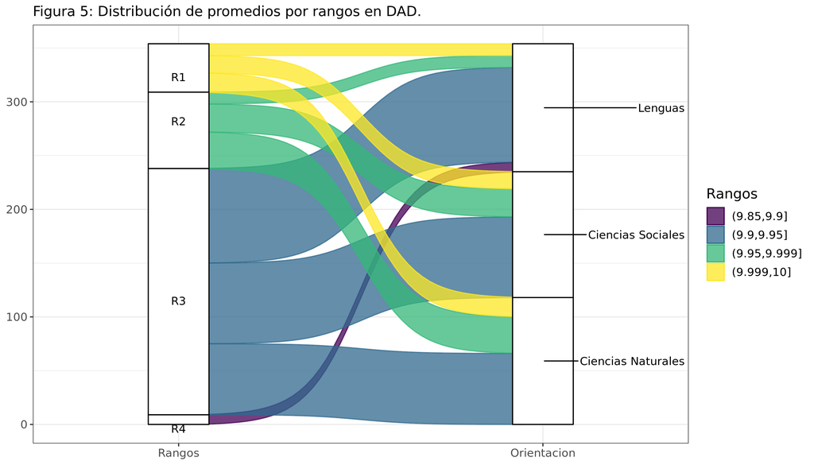

La figura 5 expone que más de la mitad de los ingresantes del DAD están en el rango R3. Es la única escuela que recibe ingresantes del rango R4, y en una única orientación, Lenguas.

## Conclusiones

En este reporte se analizan los datos provistos por la UNCuyo para el ingreso de alumnos de nivel primario a las escuelas de nivel secundario dependientes de la UNCuyo en el año 2023. Luego de todo lo expuesto en este análisis, se llegan a las siguientes conclusiones.

Una primera conclusión que se puede sacar es que CUC es la escuela a la que quieren ingresar todos. Es el colegio con mayor demanda por parte de los alumnos del CVA (ver tabla 1). Asimismo, es la escuela que alberga el porcentaje más alto de ingresantes por orden de mérito con promedio igual a 10 (ver tabla 5) y posee las notas de corte más altas para sus 3 orientaciones (ver tabla 4). En consecuencia, es más difícil ingresar al CUC que al resto de los 4 colegios. En segundo lugar se ubica el MZ, con 2 de sus 3 orientaciones con mayores notas de corte y también segundo en porcentaje de ingresantes por orden de mérito con promedio igual a 10, aunque primero en cantidad (ver tabla 5). Si se ordenan los colegios por notas de corte de mayor a menor, el colegio MZ le sigue de cerca al CUC; luego vienen MAG, LAE y finalmente el DAD.

A la luz de estos resultados, es evidente que la demanda por ingresar a Ciencias Naturales, Ciencias Sociales y Arte del CUC e Informática y Ecomonía del MZ es alta, tanto de los ingresantes por orden de mérito como por los egresados del CVA. Si bien Ciencias Naturales y Ciencias Sociales del CUC son muy demandadas, estas orientaciones ofrecen 210 y 330 plazas respectivamente (ver tabla 2) al considerar todos los colegios de la UNCuyo, ya que también se encuentra en el MAG y el DAD. Por tanto, la demanda por Informática y Arte es efectivamente la más importante, ya que solo se ofrecen 60 plazas cada una teniendo en cuenta todos los colegios de la UNCuyo.

Una solución para mitigar esta situación es la crear nuevas divisiones para Informática y Arte, tal vez en diferentes colegios si no están dadas las condiciones edilicias en MZ o CUC. De esta manera se podría satisfacer de mejor manera la actual demanda que tienen estas dos orientaciones. Por otro lado, se podría reevaluar si Lenguas realmente necesita ofrecer 120 vacantes.

Finalmente, cabe dedicar algunas palabras a los ingresantes por orden de mérito con promedio igual a 10. De un total de 967 ingresantes por orden de mérito, 306 tienen el más alto promedio. Esto se traduce en que el 32% de los ingresantes solo obtuvieron notas iguales a 10 entre cuarto y sexto grados. Si bien esta cifra parece bastante alta, sería conveniente conocer el total de postulantes, los que ingresaron y los que no, para llegar a una respuesta concluyente. Adicionalmente, como se señalara más arriba, 50 de los 54 ingresantes por orden de mérito a Informática tienen promedio 10, esto es, han sido abanderados en sus escuelas primarias de origen. Aun sin tener en cuenta a los 6 ingresantes del CVA, los cuales quizás también han aportado 1 abanderado extra. ¿Podemos llamar a Informática la Orientación de los Abanderados? ;-)